### I get asked all the time… How many players drafted “make the OHL?”

#### Project Scope

The scope of this project was to determine the **percentage of players by draft year to play a minimum of one (1) OHL career game.** I used one (1) game played as a minimum because teams need to commit financial resources to players who play a minimum of one (1) game.

My hypothesis was; the percentage of drafted players playing a minimum of one (1) game in the OHL has remained constant over the past twelve (12) year period.

#### Data

OHL draft data from 2006 to 2017 was used. I started with draft year 2006 because new rules and paradigms in hockey were established post 04-05 NHL lockout. I used 2017 as the cutoff to give every draft cohort a two year opportunity to play a game in the OHL.  
I collected data from eliteprospects.com on June 13, 2019. OHL drafts from 2006 to 2017 (12 year period) were collated using R.

#### Let’s get started:

Read in the csv file. CSV file was created utilizing a variety of scripts in R which is outside the project scope.

```r
#read in the data
ohl.data <- read.csv("ohl_data.csv") #read csv file
ohl.data <- as_tibble(ohl.data) #create a tibble from csv dataframe
```

#### Data Preparation

I use scripts to summarise the OHL tibble. See comments to further understand how the entire dataframe was grouped, summarised, filtered and the necessary data was produced.

```r
#analyse how many players were drafted in each draft year
#analyse how many games played by players per draft year
p_gp <- ohl.data %>% #create new tibble based on scraped ohl_draft tibble
  group_by(draft.year, gp) %>% #group by draft year and games played
  summarise(drafted = n()) %>% #get a count of players drafted by draft year
  summarise_each(funs(sum)) #sum the number of games played by players per draft year
```

```r
p1_gp <- ohl.data %>% #create new tibble based on scraped ohl_draft tibble
  filter(gp>=1) %>% #filter only players that played 10 or more games
  group_by(draft.year, gp) %>% #group by draft year and games played
  summarise(min.one = n()) %>% #get a count of players by draft year
  summarise_each(funs(sum)) #sum the number of games played by players per draft year
```

I then combine both objects to create a tibble that will contain the data necessary to plot the percentage of skaters to play 1 game by draft year.

```r
perc_gp1 <- left_join(p_gp, p1_gp,
                       by = "draft.year", type = "left", match = "all") %>% #join both tibbles
  mutate(percent.make = (min.one/drafted)*100) %>% #create column with percentage
  mutate_at(6, funs(round(., 0))) %>% #round the values
  select(draft.year, drafted, min.one, percent.make) #select the columns necessary
```

#### Data

Let’s take a look at the percentages of players who have played at least one (1) game in the OHL by draft year. Below is a table showing draft year, the number of players drafted, the number of players who played 1 game and the percentage of players who played 1 game per draft year.

```
## # A tibble: 12 x 4
##    draft.year drafted min.one percent.make
##         <int>   <int>   <int>        <dbl>
##  1       2006     300     150           50
##  2       2007     300     145           48
##  3       2008     302     129           43
##  4       2009     300     154           51
##  5       2010     301     140           47
##  6       2011     301     148           49
##  7       2012     303     142           47
##  8       2013     299     139           46
##  9       2014     300     130           43
## 10       2015     302     139           46
## 11       2016     301     122           41
## 12       2017     300     109           36
```

#### Analysis

A quick evaluation of the plot below shows a trendline that remains relatively constant but with a slight downward trend towards the latest drafts. To highlight the downward trend a new plot is produced with the y-axis limited to the range of values within the percent.make column.

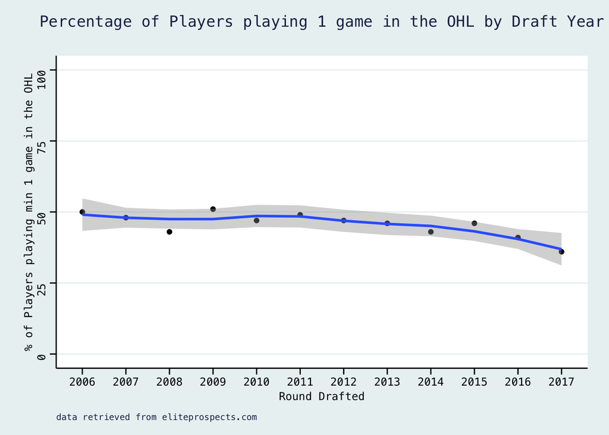

As the plot below shows, more investigation into this downward trend is necessary. I’m not convinced the drop of ~12% from draft year 2016 to draft year 2017 is due to the 2017 draft class only having a two year opportunity to play one (1) game. Historical empirical knowledge has shown very few players play their first OHL game in year three (3) of their opportunity.

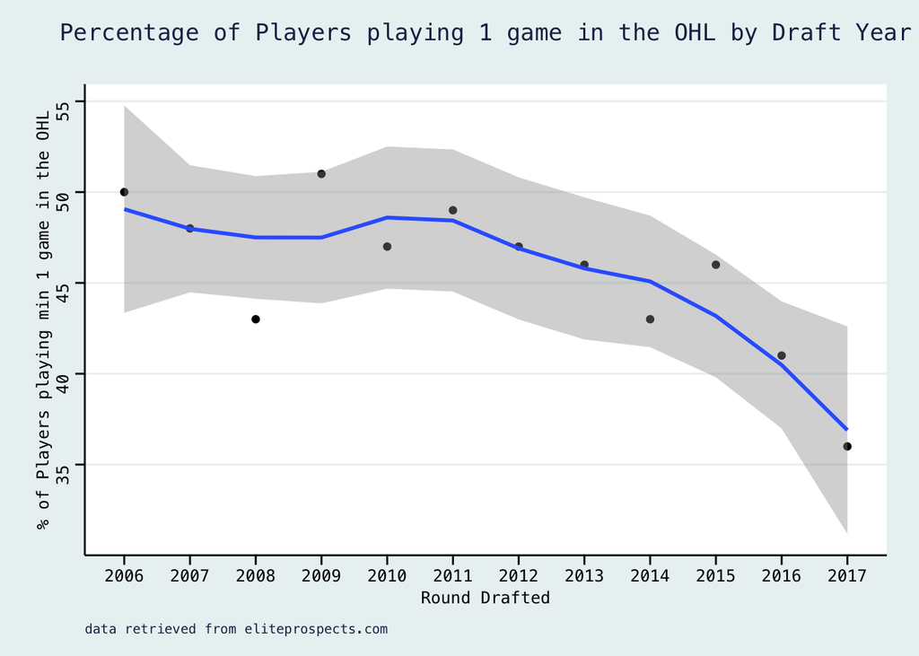

To dig deeper into this downward trendline let’s take a look at a two (2) year rolling average table with a new column labelled ra. A further plot is produced to show the trendline of the two (2) year rolling average.

```r
ra_gp1 <- perc_gp1 %>% mutate(ra = runMean(percent.make, 2)) #calculate 2 year running average
print(ra_gp1) #print tibble for analysis
```

```
## # A tibble: 12 x 5
##    draft.year drafted min.one percent.make    ra
##         <int>   <int>   <int>        <dbl> <dbl>
##  1       2006     300     150           50  NA
##  2       2007     300     145           48  49
##  3       2008     302     129           43  45.5
##  4       2009     300     154           51  47
##  5       2010     301     140           47  49
##  6       2011     301     148           49  48
##  7       2012     303     142           47  48
##  8       2013     299     139           46  46.5
##  9       2014     300     130           43  44.5
## 10       2015     302     139           46  44.5
## 11       2016     301     122           41  43.5
## 12       2017     300     109           36  38.5
```

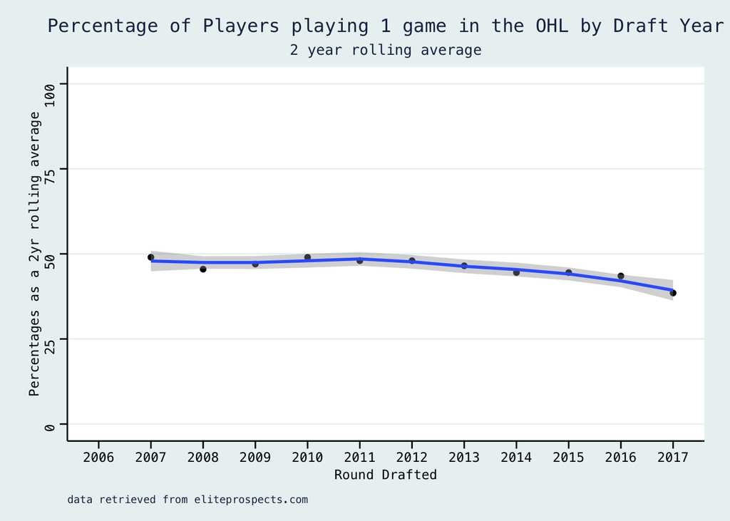

Of note, the two year rolling average of percentage of players playing a minimum of one (1) OHL game has been on a steady downward decline since 2012 and will continue in this trajectory if we believe the 2017 draft cohort will not increase after their third year of “making the OHL” opportunity.

Further evaluation will be necessary in the Spring of 2020 to verify findings.

report produced by: Clair Cornish  
report produced for: Guelph Storm  
June 14, 2019